# Facets(ggplot2)

Jeswin

14 September 2017

Reference : Cookbook for R

Sample data : We will use the tips dataset from the ‘reshape2’ package.

```r
library(reshape2)
# Look at first few rows
head(tips)
```

```
##   total_bill  tip    sex smoker day   time size
## 1      16.99 1.01 Female     No Sun Dinner    2
## 2      10.34 1.66   Male     No Sun Dinner    3
## 3      21.01 3.50   Male     No Sun Dinner    3
## 4      23.68 3.31   Male     No Sun Dinner    2
## 5      24.59 3.61 Female     No Sun Dinner    4
## 6      25.29 4.71   Male     No Sun Dinner    4
```

The point geom is used to create scatterplots. The scatterplot is most useful for displaying the relationship between two continuous variables. It can be used to compare one continuous and one categorical variable, or two categorical variables, but a variation like ‘geom_jitter’, ‘geom_count’, or ‘geom_bin2d’ is usually more appropriate.

This is a scatterplot of the tip percentage by total bill size.

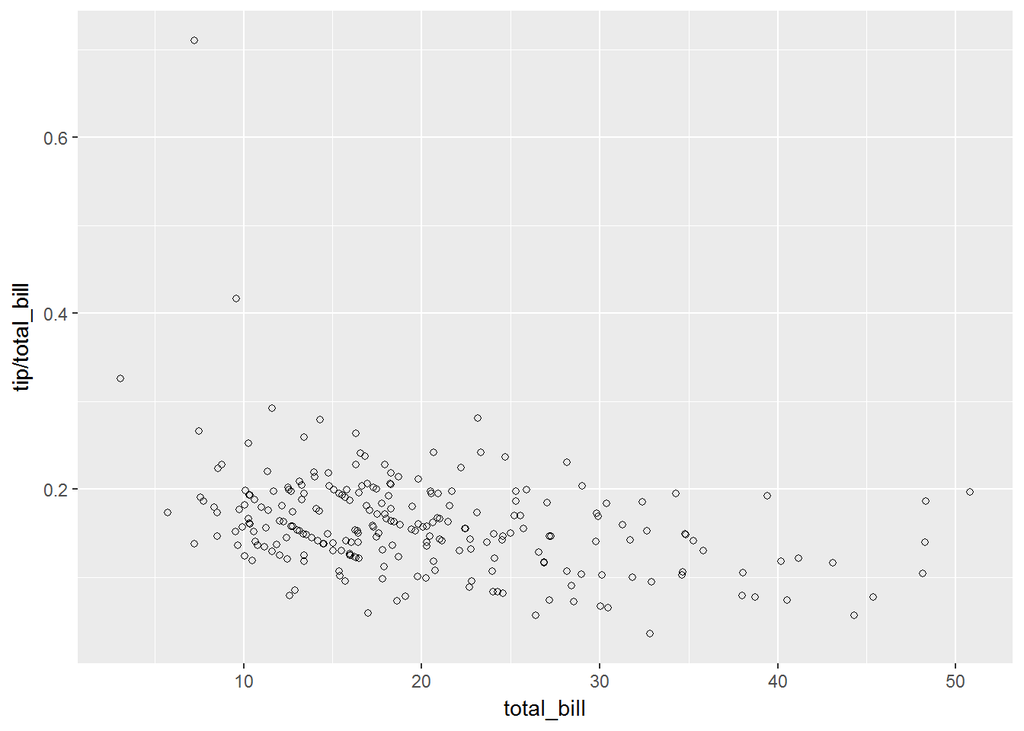

```r
library(ggplot2)
sp <- ggplot(tips, aes(x=total_bill, y=tip/total_bill)) + geom_point(shape=1)
sp
```

## facet_grid

The data can be split up by one or two variables that vary on the horizontal and/or vertical direction.

This is done by giving a formula to facet_grid(), of the form vertical ~ horizontal.

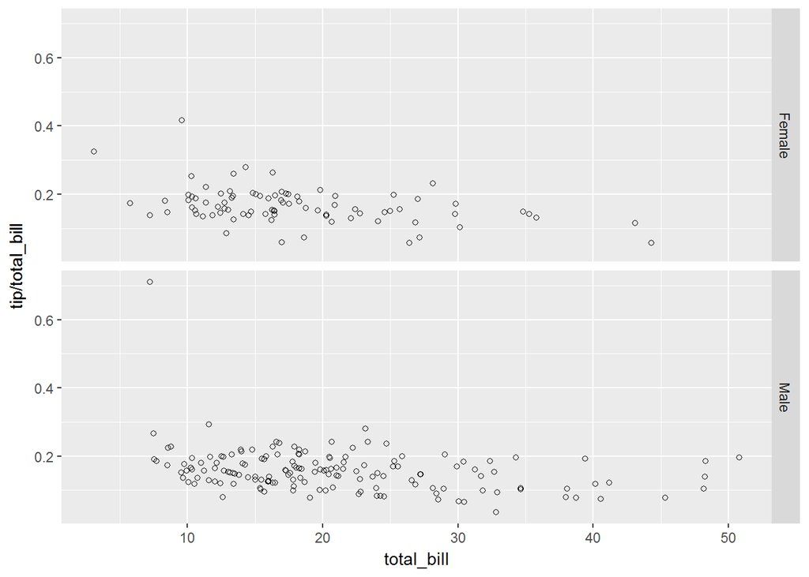

```r
# Divide by levels of "sex", in the vertical direction

sp + facet_grid(sex ~ .)
```

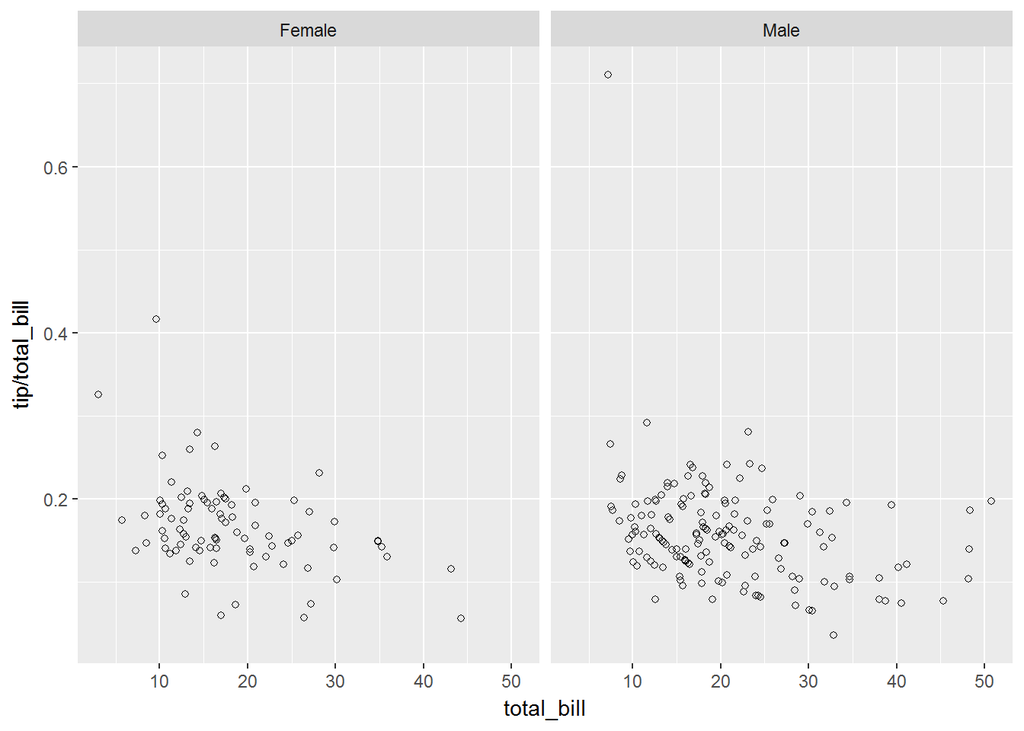

```r
# Divide by levels of "sex", in the horizontal direction
sp + facet_grid(. ~ sex)
```

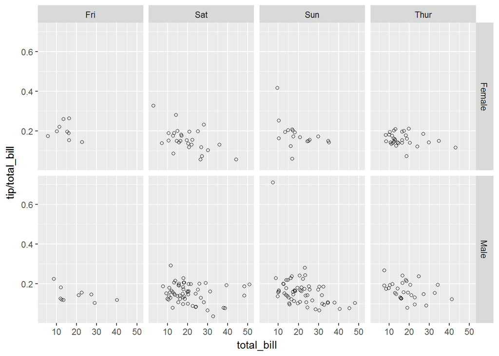

```r
# Divide with "sex" vertical, "day" horizontal
sp + facet_grid(sex ~day)
```

## facet_wrap

Instead of faceting with a variable in the horizontal or vertical direction, facets can be placed next to each other, wrapping with a certain number of columns or rows. The label for each plot will be at the top of the plot.

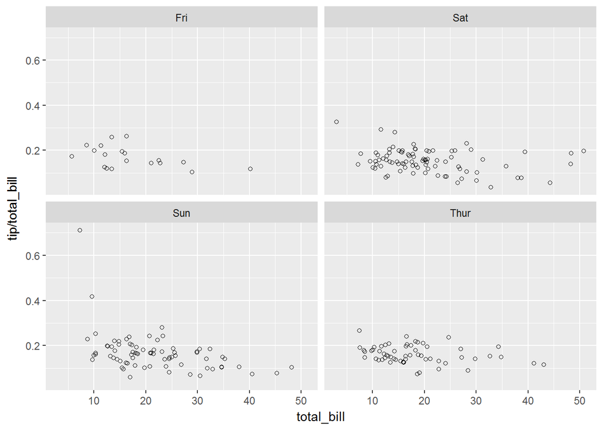

```r
# Divide by day, going horizontally and wrapping with 2 columns
sp + facet_wrap( ~ day, ncol = 2)
```

## Modifying facet label appearance

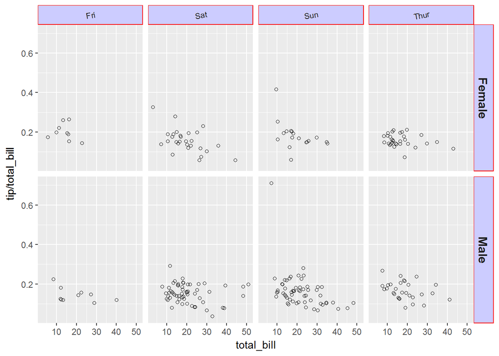

```r
sp + facet_grid(sex ~ day) +
  theme(strip.text.x = element_text(size = 8, angle = 10),
        strip.text.y = element_text(size = 12, face = "bold"),
        strip.background = element_rect(colour = "red", fill = "#CCCCFF"))
```

## Modifying facet label text

There are a few different ways of modifying facet labels. The simplest way is to provide a named vector that maps original names to new names. To map the levels of ‘sex’ from Female==>Women, and Male==>Men:

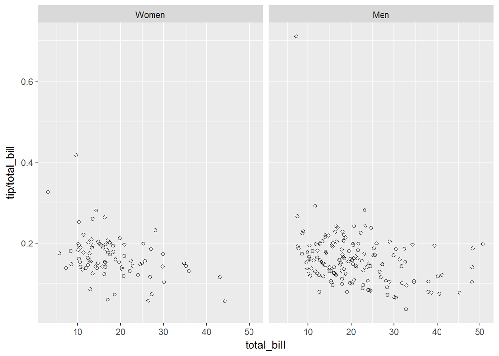

```r
labels <- c(Female = "Women", Male = "Men")
sp + facet_grid(. ~ sex, labeller = labeller(sex = labels))
```

Another way is to modify the data frame so that the data contains the desired labels:

```r
tips2 <- tips
levels(tips2$sex)[levels(tips2$sex)=="Female"] <- "Women"
levels(tips2$sex)[levels(tips2$sex)=="Male"]   <- "Men"
head(tips2)
```

```
##   total_bill  tip   sex smoker day   time size
## 1      16.99 1.01 Women     No Sun Dinner    2
## 2      10.34 1.66   Men     No Sun Dinner    3
## 3      21.01 3.50   Men     No Sun Dinner    3
## 4      23.68 3.31   Men     No Sun Dinner    2
## 5      24.59 3.61 Women     No Sun Dinner    4
## 6      25.29 4.71   Men     No Sun Dinner    4
```

Both of these will give the same result:

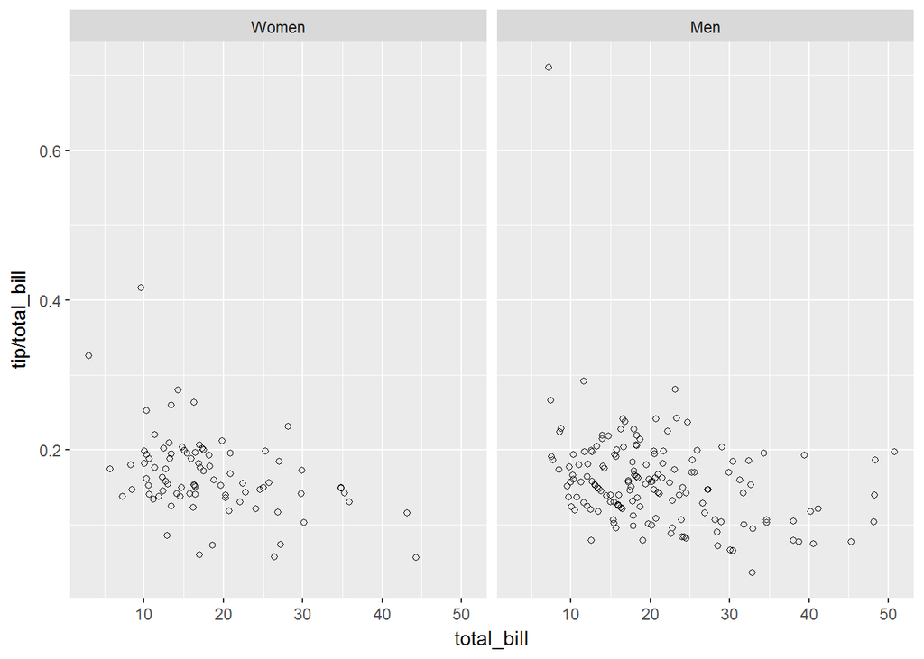

```r
sp2 <- ggplot(tips2, aes(x=total_bill, y=tip/total_bill)) + geom_point(shape=1)
sp2 + facet_grid(. ~ sex)
```

## Free scales

Normally, the axis scales on each graph are fixed, which means that they have the same size and range. They can be made independent, by setting scales to ‘free’, ‘free_x’, or ‘free_y’.

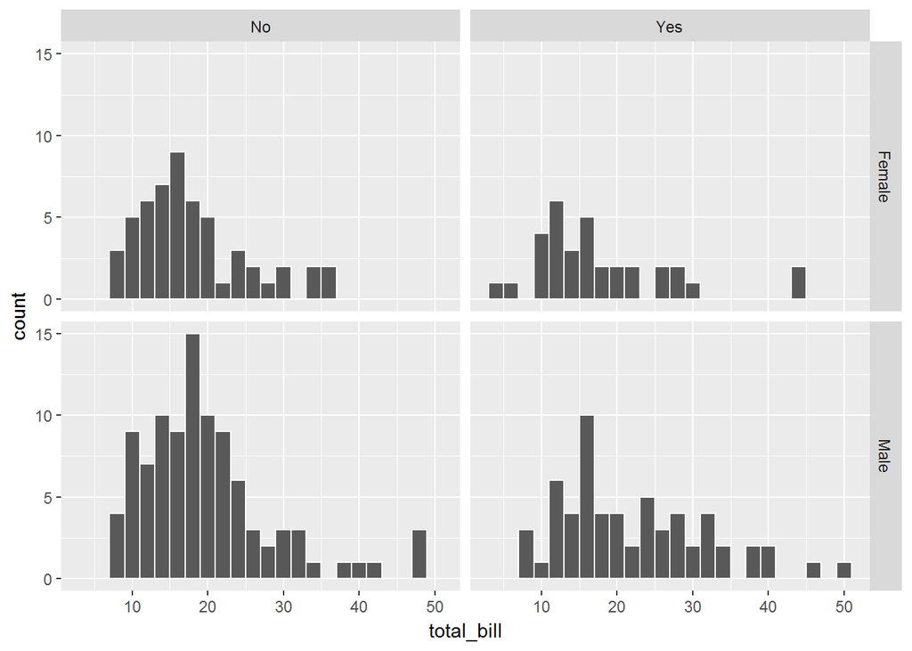

```r
# A histogram of bill sizes
hp <- ggplot(tips, aes(x=total_bill)) + geom_histogram(binwidth = 2, colour='white' )

# Histogram of total_bill, divided by sex and smoker
hp + facet_grid(sex ~ smoker)
```

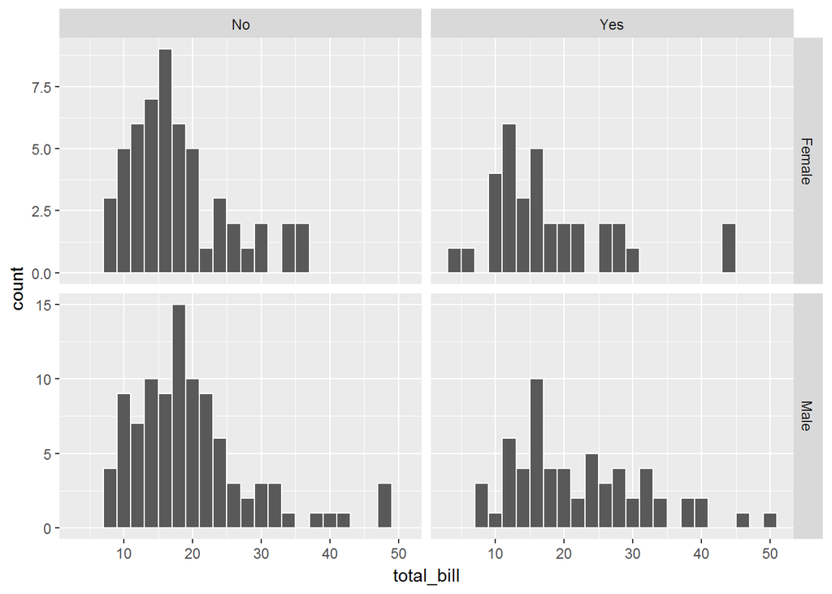

```r
# Same as above, with scales="free_y"
hp + facet_grid(sex ~ smoker, scales = "free_y")
```

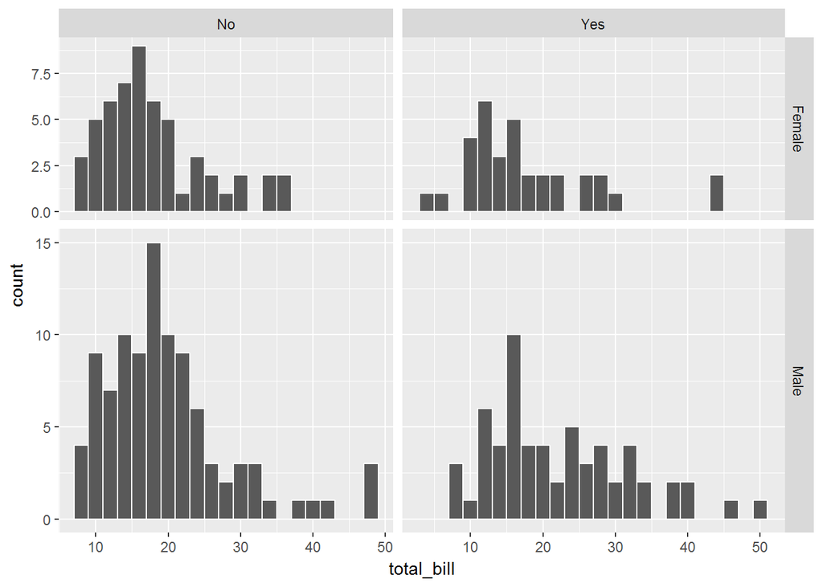

```r
#  With panels that have the same scaling, but different range (and therefore different physical sizes)
hp + facet_grid(sex ~ smoker, scales = "free", space = "free")
```

Remaining topics to study : Reference : Cookbook for R